# Outside Item Memory

### 3.2.3 Collapse the order and novelty group

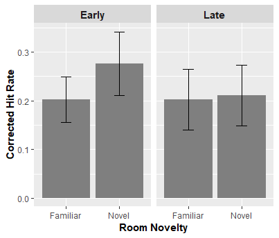

#### 3.2.3.1 Stats on it

##### 3.2.3.1.1 Using `lme`

|  | Model | df | AIC | BIC | logLik | Test | L.Ratio | p-value |
| --- | --- | --- | --- | --- | --- | --- | --- | --- |
| baseline | 1 | 5 | -104.0251 | -88.64928 | 57.01258 |  |  |  |
| NoveltyModel | 2 | 6 | -105.2397 | -86.78861 | 58.61983 | 1 vs 2 | 3.214502 | 0.0730 |
| OrderModel | 3 | 7 | -105.4115 | -83.88523 | 59.70573 | 2 vs 3 | 2.171794 | 0.1406 |
| repeatedModel | 4 | 8 | -105.6439 | -81.04246 | 60.82193 | 3 vs 4 | 2.232402 | 0.1351 |

```
Linear mixed-effects model fit by maximum likelihood
 Data: Curiosity.Recall.Old.Order.Novelty[!SubjectNo %in% bad.ps.less.strict]
```

|  | AIC | BIC | logLik |
| --- | --- | --- | --- |
|  | -106 | -81 | 60.8 |

```
Random effects:
 Formula: ~1 | SubjectNo
        (Intercept)
StdDev:   0.1213897

 Formula: ~1 | Group %in% SubjectNo
        (Intercept)
StdDev:  0.02488406

 Formula: ~1 | ItemOrderType %in% Group %in% SubjectNo
        (Intercept)   Residual
StdDev:   0.1323785 0.03603831

Fixed effects: CorrSeenHit ~ Group + ItemOrderType + Group:ItemOrderType
```

|  | Value | Std.Error | DF | t-value | p-value |
| --- | --- | --- | --- | --- | --- |
| (Intercept) | 0.20250000 | 0.02960314 | 78 | 6.840491 | 0.0000 |
| GroupNovel | 0.07361111 | 0.03157574 | 39 | 2.331255 | 0.0250 |
| ItemOrderTypeLate | 0.00000000 | 0.03106884 | 78 | 0.000000 | 1.0000 |
| GroupNovel:ItemOrderTypeLate | -0.06527778 | 0.04393797 | 78 | -1.485680 | 0.1414 |

```
 Correlation:
                             (Intr) GrpNvl ItmOTL
GroupNovel                   -0.533
ItemOrderTypeLate            -0.525  0.492
GroupNovel:ItemOrderTypeLate  0.371 -0.696 -0.707

Standardized Within-Group Residuals:
        Min          Q1         Med          Q3         Max
-0.47458604 -0.17660411 -0.03995532  0.15701004  0.63884681

Number of Observations: 160
Number of Groups:
                              SubjectNo                    Group %in% SubjectNo
                                     40                                      80
ItemOrderType %in% Group %in% SubjectNo
                                    160
```

##### 3.2.3.1.2 Using `ezANOVA`

```r
repeatedModel<-ezANOVA(data = Curiosity.Recall.Old.Order.Novelty[!SubjectNo %in% bad.ps.less.strict], dv = .(CorrSeenHit), wid = .(SubjectNo),  within = .(Group, ItemOrderType), type = 3, detailed = TRUE)
```

```
Converting "SubjectNo" to factor for ANOVA.Converting "Group" to factor for ANOVA.Converting "ItemOrderType" to factor for ANOVA.
```

```r
options(digits = 3)
repeatedModel
```

|  | Effect | DFn | DFd | SSn | SSd | F | p | p<.05 | ges |
| --- | --- | --- | --- | --- | --- | --- | --- | --- | --- |
| 1 | (Intercept) | 1 | 39 | 7.9556 | 3.160 | 98.18 | 3.32e-12 | * | 0.59264 |
| 2 | Group | 1 | 39 | 0.0671 | 0.802 | 3.26 | 7.86e-02 |  | 0.01213 |
| 3 | ItemOrderType | 1 | 39 | 0.0426 | 0.941 | 1.77 | 1.92e-01 |  | 0.00773 |
| 4 | Group:ItemOrderType | 1 | 39 | 0.0426 | 0.565 | 2.94 | 9.42e-02 |  | 0.00773 |

```
NA
```

##### 3.2.3.1.3 Simple effects for the “early” group

```
    Paired t-test

data:  CorrSeenHit by Group
t = -2.4759, df = 39, p-value = 0.01774
alternative hypothesis: true difference in means is not equal to 0
95 percent confidence interval:
 -0.13374775 -0.01347447
sample estimates:
mean of the differences
            -0.07361111
```

##### 3.2.3.1.4 Simple effects for the “late” group

```
    Paired t-test

data:  CorrSeenHit by Group
t = -0.28273, df = 39, p-value = 0.7789
alternative hypothesis: true difference in means is not equal to 0
95 percent confidence interval:
 -0.06795120  0.05128453
sample estimates:
mean of the differences
           -0.008333333
```

# 4 Curiosity Benefits

We hypothesed that the higher the curiosity rating was, the better the item memory should be.

## 4.1 Mean accuracy of item memory as a function of curiosity rating

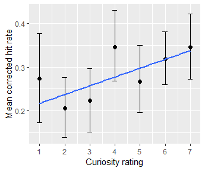

### 4.1.1 Testing the relationship between mean accuracy of item memory and curiosity rating

Build models with item memory accuracy as $y$ and examine effects of curiosity rating by including it into the model and then comparing the model fits.

- `baseline.rating` is the model with only an intercept, showing no change in item memory as a function of curiosity rating.
- `rating.intercept` is the model with $\small CuriosityRating$ included, showing the effects of curiosity rating.
- `rating.slope` is the model allowing the slope (i.e., relationship between item memory and curiosity rating) varying across participants.

|  | Model | df | AIC | BIC | logLik | Test | L.Ratio | p-value |
| --- | --- | --- | --- | --- | --- | --- | --- | --- |
| baseline.rating | 1 | 3 | -77.86584 | -67.47434 | 41.93292 |  |  |  |
| rating.intercept | 2 | 4 | -81.97683 | -68.12151 | 44.98842 | 1 vs 2 | 6.110996 | 0.0134 |
| rating.slope | 3 | 6 | -82.48982 | -61.70683 | 47.24491 | 2 vs 3 | 4.512984 | 0.1047 |

#### 4.1.1.1 Parameter estimates in the complete model

```r
summary(rating.slope)
```

```
Linear mixed-effects model fit by maximum likelihood
 Data: OutsideObjectsMemory[!SubjectNo %in% bad.ps.less.strict]
```

|  | AIC | BIC | logLik |
| --- | --- | --- | --- |
|  | -82.5 | -61.7 | 47.2 |

```
Random effects:
 Formula: ~1 + CuriosityRating | SubjectNo
 Structure: General positive-definite, Log-Cholesky parametrization
                StdDev     Corr
(Intercept)     0.17748559 (Intr)
CuriosityRating 0.03043525 -0.65
Residual        0.16601016

Fixed effects: CorrSeenHit ~ CuriosityRating
```

|  | Value | Std.Error | DF | t-value | p-value |
| --- | --- | --- | --- | --- | --- |
| (Intercept) | 0.20826961 | 0.04109524 | 195 | 5.067974 | 0.0000 |
| CuriosityRating | 0.01634939 | 0.00786035 | 195 | 2.079982 | 0.0388 |

```
 Correlation:
                (Intr)
CuriosityRating -0.806

Standardized Within-Group Residuals:
       Min         Q1        Med         Q3        Max
-2.0741458 -0.6138912 -0.1081578  0.5504126  2.5474591

Number of Observations: 236
Number of Groups: 40
```

#### 4.1.1.2 Plot the model

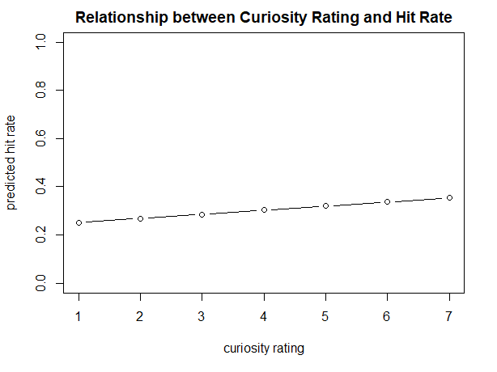

## 4.2 Does the relationship with curiosity rating depend on item order?

### 4.2.1 Curiosity Rating

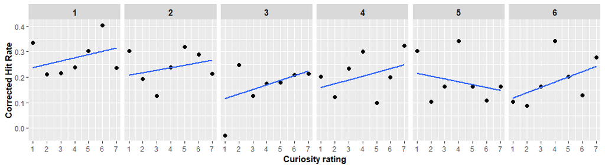